# Assignment Guide

## Sample with t.test

**Structural adaptation**: Average cross sectional vessel area

**Categories**:

- Tall(Average plant height is greater than 3 meters)

```r
cat1 <-data1[0:10,0:3]
cat1
```

```
##           Family                   Binomial        A.mm
## 1     Rhamnaceae      Krugiodendron ferreum 0.002922467
## 2       Fabaceae          Tamarindus indica 0.010386891
## 3  Anacardiaceae        Astronium urundeuva 0.009503318
## 4       Fabaceae      Dalbergia melanoxylon 0.013273229
## 5       Fabaceae         Swartzia corrugata 0.018385386
## 6       Fabaceae Caesalpinia paraguariensis 0.003848451
## 7       Fabaceae            Dinizia excelsa 0.025446900
## 8   Boraginaceae       Patagonula americana 0.004133158
## 9   Bignoniaceae        Tabebuia chrysantha 0.002281189
## 10      Fabaceae          Bocoa prouacensis 0.018385386
```

- Short(Average plant height is less than 3 meters)

```r
cat2 <- data1[11:20,0:3]
cat2
```

```
##             Family               Binomial        A.mm
## 11   Euphorbiaceae      Gymnanthes lucida 0.000855299
## 12        Fabaceae       Dipteryx odorata 0.024052819
## 13    Bignoniaceae  Tabebuia serratifolia 0.004964109
## 14 Erythroxylaceae  Erythroxylum pulchrum 0.001590431
## 15        Fabaceae Pterocarpus santalinus 0.041547563
## 16      Sapotaceae    Manilkara bidentata 0.009852035
## 17        Fabaceae        Acacia erioloba 0.015174678
## 18     Sapindaceae       Dodonaea viscosa 0.002457511
## 19  Rhizophoraceae      Rhizophora mangle 0.003033290
## 20        Fabaceae    Zollernia paraensis 0.006939778
```

Means and standard deviations of both group of data:

```r
mean1 <- mean(cat1[,3])
mean2 <- mean(cat2[,3])

sd1 <- sd(cat1[,3])
sd2 <- sd(cat2[,3])

mean1
```

```
## [1] 0.01085664
```

```r
mean2
```

```
## [1] 0.01104675
```

```r
sd1
```

```
## [1] 0.00792283
```

```r
sd2
```

```
## [1] 0.01292314
```

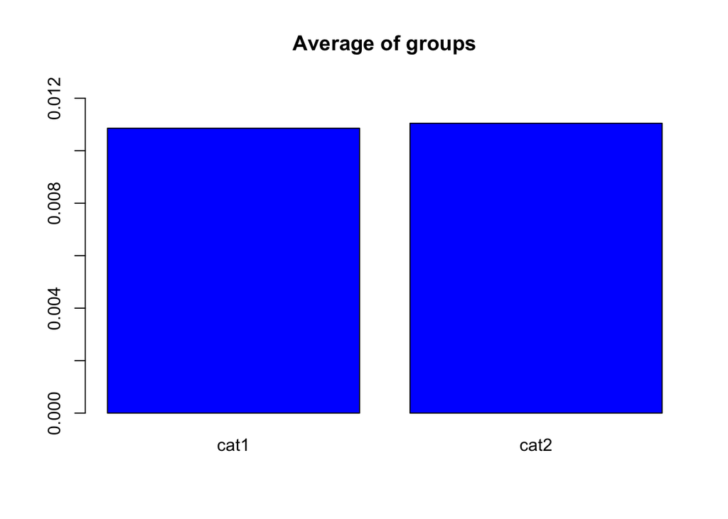

```r
barplot(c(mean1,mean2), names.arg = c('cat1','cat2'),main ="Average of groups", ylim = c(0,0.0125), col = c('blue','blue'))
```

For the t.test if we want to evaluate $\alpha = 0.05$ if our p-value is greater than our $\alpha$ both means are not statistically different (based on the datasets). Althought, if the p-value is less than $\alpha$ then both means are statistically different:

```r
t.test(cat1[,3], cat2[,3], alternative = 'two.sided',paired = TRUE)
```

```
##
##  Paired t-test
##
## data:  cat1[, 3] and cat2[, 3]
## t = -0.052951, df = 9, p-value = 0.9589
## alternative hypothesis: true difference in means is not equal to 0
## 95 percent confidence interval:
##  -0.008312154  0.007931926
## sample estimates:
## mean of the differences
##           -0.0001901138
```

For more information about t.tests and statistical analysis refer to: https://ahurford.github.io/quant-guide-all-courses/statistics.html